# Penicilinas

Febrero 2022.

## Breve historia.

- Encontrada por A. Fleming en 1928.
- Estabilizada por H. Florey, C. Fletcher, E. Chain y N. Heatley en 1940.
- Albert Alexander fue el primer paciente en 1941.
- A. Moyer y N. Heatley simplifican y optimizan la obtención en 1941.
- Comercializada desde 1943.

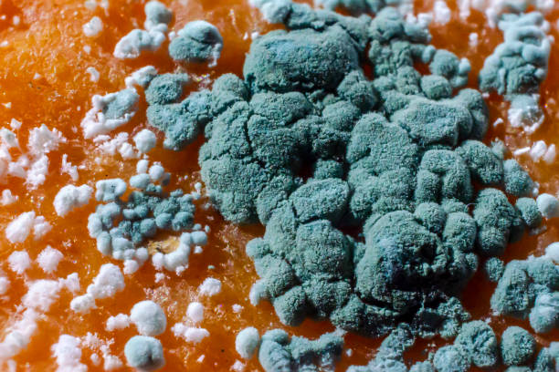

*Penicillium notatum*.

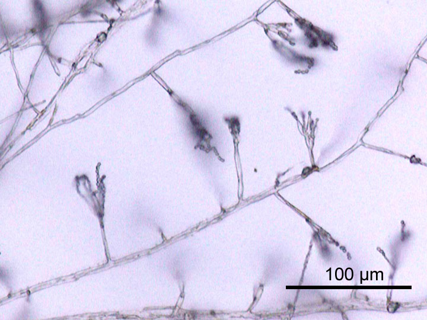

Hifas y conidióforos de *Penicillium*.

[figure not shown]

Ácido 6-aminopenicilánico.  
Anillo \(\beta\)-lactámico + anillo de tiazolidina

[figure not shown]

## Clasificación (I).

- Naturales.
- Sintéticas.
- Semisintéticas.

## Clasificación (II).

- Penicilina G y V.
- Aminopenicilinas.
- Resistentes a la penicilinasa.
- Con actividad antimicrobiana extendida.

## Penicilina G.

- Natural.
- CAS 61-33-6.
- Administración parenteral.
- Absorción en 15-30 min.
- Biodisponibilidad de entre 30 y 60%.
- Cerca del 16-30% es metabolizado.
  - Ácido penicilóico.
  - Ácido 6-aminopenicilánico.
- Excreción renal. Hepático y biliar en menor medida.
- Vida media de 30 minutos. 2 horas en adultos mayores.

## Penicilina V.

- Sintética.
- CAS 87-08-1.
- Administración oral.
  - 125 mg \(\longrightarrow\) 0.2 a 0.7 \(\mu\)g/mL en 120 min.
  - 500 mg \(\longrightarrow\) 3 a 5 \(\mu\)g/mL en 30-60 min.
- Biodisponibilidad de entre 25 y 60%.
- Cerca del 35-70% es metabolizado.
  - Ácido penicilóico.
  - Ácido 6-aminopenicilánico.
- Excreción renal.
- Vida media de 30 minutos. 4 horas en pacientes con IR.

## Aminopenicilinas.

- Semisintéticas.
- Expanden la actividad de la Penicilina G.
- Incluye a bacterias gramnegativas.
- Son destruidas por la \(\beta\)-lactamasa.
  - Produce la hidrólisis del anillo \(\beta\)-lactámico.
  - Se administran junto con un inhibidor de la \(\beta\)-lactamasa.
- Ejemplos.
  - Ampicilina y amoxicilina.

## Penicilinas resistentes a la penicilinasa.

- Resistentes a la hidrólisis.
  - Causada por la penicilinasa.
    - Producida por estafilococos.
- Menos activas que la Penicilina G.
- Ejemplos.
  - Oxacilina y dicloxacilina.

## Con actividad antimicrobiana extendida.

- Acción extendida.
  - *Pseudomonas*.
  - *Enterobacter*.
  - *Proteus*.
- Ejemplos.
  - Azlocilina y carbenicilina.

## Mecanismo de acción (I).

- Inhibición de la síntesis de la pared bacteriana.
  - Fase citoplasmática.
  - Fase de transporte de precursores.
  - Fase de organización estructural del peptidoglucano.

## Mecanismo de acción (II).

- En la fase de organización los precursores se ensamblan.
  - Proteínas fijadoras de penicilina (PBP).
    - Entrelazan los componentes del peptidoglucano.
      - Estructura básica de la pared celular bacteriana.

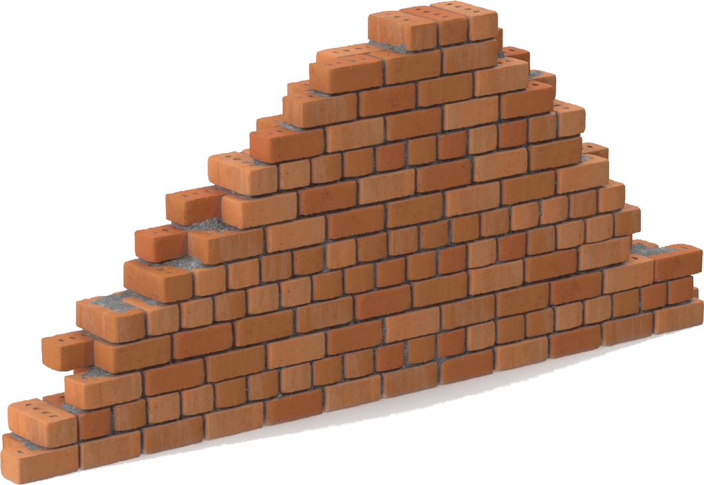

Pared = Peptidoglucano. Ladrillos = Precursores. Mezcla de cemento = PBP.

## Mecanismo de acción (III).

- Las penicilinas bloquean a las PBP.
  - Anillo \(\beta\)-lactámico \(\simeq\) residuo acil-D-alanin-D-alanina.
    - El acil-D-alanin-D-alanina es el sustrato natural de las PBP.

## Mecanismo de acción (IV).

- Proteínas fijadoras de penicilina (PBP).
  - PBP-1a y PBP-1b.
    - Responsables de la elongación.
    - El bloqueo produce esferoplastos.
  - PBP-2.
    - Determina la forma bacteriana.
    - El bloqueo produce formas ovoideas.
  - PBP-3.
    - Intervienen en la división bacteriana.
    - El bloqueo produce forma filamentosas sin septos.
  - PBP-4, PBP-5 y PBP-6.
    - Participan en la polimerización del peptidoglucano.
    - El bloqueo impide la polimerización.

## Mecanismo de acción (V).

- Las penicilinas causan problemas y deformidades.
  - Activan un sistema de enzimas líticas (autolisinas).
    - Provoca la muerte bacteriana.

## Mecanismo de acción (VI).

- Se requiere.
  - La bacteria se halle en crecimiento activo.
  - La bacteria se encuentre en un medio isotónico o hipotónico.
    - Favorece el estallido celular.
- Más activas en bacterias grampositivas.
  - Contienen más peptidoglucano.

## Usos terapéuticos.

- Actinomicosis.
- Difteria.
- Infecciones.
  - Anaerobios.
  - Estafilococos.
  - Enterococos.
  - Estreptococos.
  - Gonococos.
  - Meningococos.
  - Neumococos.
- Neumonía y meningitis por neumococos.
- Sífilis.

## Reacciones adversas.

- Anafilaxia.
- Angioedema.
- Broncoespasmo.
- Dermatitis exfoliativa.
- Erupción maculopapular.
- Fiebre.
- Urticaria.
- Vasculitis.

## Preguntas.

1. ¿Quiénes lograron estabilizar la penicilina?
2. ¿Cómo está formado el anillo \(\beta\)-lactámico?
3. ¿Cuál es la clasificación de las penicilinas?
4. Mencione un uso terapéutico de las penicilinas.
5. ¿Cuáles son las reacciones adversas más graves a las penicilinas?

## Bibliografía.

1. Brunton, Laurence L., Hilal-Dandan, Randa, Knollmann, Björn C. (2019). *Goodman & Gilman, Las Bases Farmacológicas de la Terapéutica* (13th ed.). McGraw Hill Interamericana Editores, S.A. de C.V.

2. Calvo, Jorge, Martínez-Martínez, Luis. (2009). Mecanismos de Acción de los Antimicrobianos. *Enfermedades Infecciosas y Microbiología Clínica*, *27*(1), 44–52. https://doi.org/10.1016/j.eimc.2008.11.001

3. DrugBank. (2005). *Benzylpenicillin: Uses, Interactions, Mechanism of Action*. https://go.drugbank.com/drugs/DB01053

4. DrugBank. (2005). *Phenoxymethylpenicillin: Uses, Interactions, Mechanism of Action*. https://go.drugbank.com/drugs/DB00417

5. Giraldo-Hoyos, Nicolás. (2021). History of Penicillin: Beyond Heroes, a Social Construction. *Iatreia*, *34*(2). https://doi.org/10.17533/udea.iatreia.79

6. National Center for Biotechnology Information. (2022). *PubChem Compound Summary for CID 5904, Penicillin g*. https://pubchem.ncbi.nlm.nih.gov/compound/5904

7. National Center for Biotechnology Information. (2022). *PubChem Compound Summary for CID 6869, Penicillin v*. https://pubchem.ncbi.nlm.nih.gov/compound/Penicillin-v